# Holtemme global transcriptome structure

Camilo Escobar

Overview

This document reproduces the global transcriptome structure analyses for the Holtemme *Gammarus pulex* study. The goal of this section is to characterize how transcriptomic profiles are organized across the German river gradient before integrating chemical exposure data or performing differential expression analysis. In the publication workflow, stations are displayed using the manuscript shorthand `H2-H7`, corresponding to the legacy site IDs `HOL01-HOL06`.

The analyses in this report are deliberately unsupervised and descriptive. They are intended to address the following questions:

1. Does site identity structure global expression patterns?
2. Are any samples clear transcriptomic outliers?
3. Do downstream sites diverge progressively from the reference condition?
4. Are there sharper local discontinuities along the river gradient?

This report is standalone and reproducible. It writes all outputs to a results-specific project directory without overwriting other analyses.

Biological rationale

Field transcriptomics in wild sentinel organisms is inherently noisy because samples integrate multi- ple sources of biological and environmental variation. Before moving to mechanistic interpretation, it is essential to establish whether the data contain a coherent large-scale expression structure across the river gradient.

In this section, we therefore focus on exploratory multivariate analyses of the variance-stabilized expression matrix. These methods do not identify causal drivers by themselves, but they provide an essential first biological overview of whether wild Gammarus pulex exhibits structured molecular differentiation across the Holtemme gradient.

Importantly, this report does not yet attempt to explain the observed structure using chem- istry, physico-chemical variables, or differential expression contrasts. Those steps belong to later manuscript sections.

# 1 Analytical scope

This script:

- uses only the German / Holtemme samples
- uses the raw gene count matrix as input
- applies a simple low-count filter for stable ordination
- uses blind variance-stabilizing transformation (VST) for unsupervised exploration
- summarizes transcriptome structure using:
  - PCA
  - scree plots
  - sample-to-sample distance heatmaps
  - hierarchical clustering
  - top-variable-gene heatmaps
  - PERMANOVA and dispersion tests
  - outlier diagnostics
  - site-centroid distance summaries

This script does not:

- integrate chemistry
- use environmental variables as predictors
- run DESeq2 differential expression testing
- make mechanistic claims about pathway activation

# 2 Input and output structure

This report assumes it is run from the project home directory and uses the following inputs:

- raw count matrix: `02_inputs/counts_raw_gene_level.tabular`
- metadata file: `01_metadata/FORMAS_Metadata.xlsx`

All outputs are written to a results-specific external folder:

- `Results_01_Global_Transcriptome_Structure/`
  - `plots/`
  - `tables/`
  - `matrices/`
  - `logs/`

# 3 0. Setup and configuration

This first step loads the required packages, defines paths, and sets analysis parameters. Keeping all settings together at the beginning makes the workflow easier to audit, update, and rerun.

```r
knitr::opts_chunk$set(echo = TRUE, warning = FALSE, message = FALSE)
options(stringsAsFactors = FALSE)

required_pkgs <- c(
  "DESeq2",
  "SummarizedExperiment",
  "ggplot2",
  "ggrepel",
  "pheatmap",
  "readxl",
  "tibble",
  "readr",
  "dplyr",
  "tidyr",
  "vegan",
  "RColorBrewer"
)

missing_pkgs <- required_pkgs[!vapply(required_pkgs, requireNamespace, logical(1), quietly = TRUE)]
if (length(missing_pkgs) > 0) {
  stop(
    "Missing required packages: ",
    paste(missing_pkgs, collapse = ", "),
    "\nPlease install them before running this report."
  )
}

for (p in required_pkgs) {
  suppressPackageStartupMessages(library(p, character.only = TRUE))
}

project_dir <- getwd()
source(file.path(project_dir, "support", "workflow_helpers.R"))
sync_rstudio_pandoc()
label_bundle <- get_publication_labels(project_dir)

count_file <- file.path(
  project_dir,
  "02_inputs",
  "counts_raw_gene_level.tabular"
)

metadata_file <- file.path(project_dir, "01_metadata", "FORMAS_Metadata.xlsx")

results_dir <- make_results_dir(project_dir, 1, "Global_Transcriptome_Structure")
plots_dir <- file.path(results_dir, "plots")
tables_dir <- file.path(results_dir, "tables")
matrices_dir <- file.path(results_dir, "matrices")
logs_dir <- file.path(results_dir, "logs")

for (d in c(results_dir, plots_dir, tables_dir, matrices_dir, logs_dir)) {
  if (!dir.exists(d)) dir.create(d, recursive = TRUE)
}

# Analysis parameters
country_keep <- "Germany"
site_levels <- label_bundle$site_levels_simple
reference_site <- "H2"
min_count <- 10
min_samples <- 3
ntop_heatmap <- 500
pca_n_axes_for_centroid_dist <- 5
plot_dpi <- 300
plot_width <- 8
plot_height <- 6
label_points <- TRUE

# Shared border settings for publication panels
panel_border_col <- "black"
panel_border_lwd <- 0.25
```

# 4 1. Helper functions

This section defines small utility functions for cleaner downstream code. The intention is not to hide analysis logic, but to keep repetitive tasks standardized and readable.

```r
standardize_ids <- function(x) {
  x <- as.character(x)
  x <- trimws(x)
  x <- gsub("\\s+", "_", x)
  x <- gsub("-", "_", x)
  x <- gsub("[^A-Za-z0-9_]+", "", x)
  x
}

save_plot_dual <- function(plot_obj, filename_stub, width = 8, height = 6, dpi = 300) {
  ggplot2::ggsave(
    filename = file.path(plots_dir, paste0(filename_stub, ".png")),
    plot = plot_obj,
    width = width,
    height = height,
    dpi = dpi
  )
  ggplot2::ggsave(
    filename = file.path(plots_dir, paste0(filename_stub, ".pdf")),
    plot = plot_obj,
    width = width,
    height = height,
    dpi = dpi
  )
}

write_table_safe <- function(df, filename) {
  readr::write_csv(df, file.path(tables_dir, filename))
}
```

# 5 2. Load raw count matrix

We begin with the raw gene count matrix because unsupervised transcriptome structure should be assessed from count-derived expression values rather than from downstream contrast-specific subsets.

At this stage, we only perform minimal preprocessing:

- set the first column as gene IDs
- standardize sample and gene identifiers
- remove genes with zero counts across all retained samples

```r
counts_df <- utils::read.delim(count_file, check.names = FALSE)
colnames(counts_df)[1] <- "gene_id"
counts_df$gene_id <- standardize_ids(counts_df$gene_id)
counts_df <- counts_df[!duplicated(counts_df$gene_id), , drop = FALSE]
rownames(counts_df) <- counts_df$gene_id
counts_df$gene_id <- NULL

counts_mat <- as.matrix(counts_df)
storage.mode(counts_mat) <- "integer"
colnames(counts_mat) <- standardize_ids(colnames(counts_mat))
counts_mat <- counts_mat[rowSums(counts_mat) > 0, , drop = FALSE]

cat("Raw count matrix dimensions:\n")
```

```
## Raw count matrix dimensions:
```

```r
cat(" Genes:", nrow(counts_mat), "\n")
```

```
##  Genes: 443656
```

```r
cat(" Samples:", ncol(counts_mat), "\n")
```

```
##  Samples: 30
```

# 6 3. Load metadata and subset to Germany / Holtemme samples

The metadata provide the biological structure needed for grouping and interpretation. For this manuscript section, only the German Holtemme samples are relevant. Restricting the analysis at this stage is important because mixing geographically distinct populations would risk conflating river-gradient structure with broader population or country effects.

From the metadata, we use:

- `sample_code` as the unique sample identifier
- `site_id` as the main grouping factor for transcriptome structure
- `sampling_sites` as a human-readable site descriptor
- `site_type` as an auxiliary descriptor
- `country` for subsetting

Other environmental fields are retained for traceability, but they are not used as explanatory variables in this report.

```r
meta_raw <- readxl::read_excel(metadata_file)
meta_raw <- as.data.frame(meta_raw)
station_crosswalk <- label_bundle$station_tbl

required_cols <- c("sample_code", "sampling_sites", "site_id", "country", "site_type")
missing_cols <- setdiff(required_cols, colnames(meta_raw))
if (length(missing_cols) > 0) {
  stop("Metadata is missing required columns: ", paste(missing_cols, collapse = ", "))
}

meta_raw$sample_code <- standardize_ids(meta_raw$sample_code)
meta_raw$site_id <- standardize_ids(meta_raw$site_id)
meta_raw$sampling_sites <- as.character(meta_raw$sampling_sites)
meta_raw$site_type <- as.character(meta_raw$site_type)
meta_raw$country <- as.character(meta_raw$country)

meta_de <- meta_raw %>%
  dplyr::filter(country == country_keep) %>%
  dplyr::left_join(
    station_crosswalk %>%
      dplyr::select(.data$legacy_site_id, .data$station_tag, .data$display_label, .data$site_name),
    by = c("site_id" = "legacy_site_id")
  ) %>%
  dplyr::distinct(sample_code, .keep_all = TRUE)

cat("Metadata rows retained for Germany:", nrow(meta_de), "\n")
```

```
## Metadata rows retained for Germany: 30
```

# 7 4. Match metadata and count matrix

Accurate sample matching is one of the most critical quality-control steps in RNA-seq analysis. Before any ordination is performed, the expression matrix and metadata must be synchronized so that every sample column corresponds exactly to the correct metadata row.

```r
common_samples <- intersect(colnames(counts_mat), meta_de$sample_code)

if (length(common_samples) == 0) {
  stop("No overlapping German sample IDs were found between the count matrix and metadata.")
}

counts_mat <- counts_mat[, common_samples, drop = FALSE]
meta <- meta_de[match(common_samples, meta_de$sample_code), , drop = FALSE]
rownames(meta) <- meta$sample_code

site_levels_present <- site_levels[site_levels %in% unique(meta$station_tag)]

meta$sample <- meta$sample_code
meta$site <- factor(meta$station_tag, levels = site_levels_present)
meta$short_name <- meta$sample_code

stopifnot(identical(colnames(counts_mat), meta$sample))

cat("Matched German dataset:\n")
```

```
## Matched German dataset:
```

```r
cat(" Samples in expression matrix:", ncol(counts_mat), "\n")
```

```
##  Samples in expression matrix: 30
```

```r
cat(" Sites represented:", length(unique(meta$site)), "\n")
```

```
##  Sites represented: 6
```

```r
write_table_safe(meta, "metadata_matched_germany.csv")
```

# 8 5. Initial sample-level QC summary

Before transforming the data, it is useful to inspect broad sample-level properties such as library size and the number of detected genes. These summaries do not define transcriptome structure directly, but they help identify whether apparent outliers may simply reflect unusually small libraries or poor transcript detection.

```r
sample_qc <- data.frame(
  sample = colnames(counts_mat),
  site = meta$site,
  sampling_sites = meta$sampling_sites,
  site_type = meta$site_type,
  library_size = colSums(counts_mat),
  detected_genes = colSums(counts_mat > 0),
  stringsAsFactors = FALSE
)

write_table_safe(sample_qc, "sample_qc_basic.csv")

knitr::kable(
  head(sample_qc, 10),
  caption = "Basic sample-level QC metrics.",
  row.names = FALSE
)
```

Basic sample-level QC metrics.

| sample | site | sampling_sites | site_type | library_size | detected_genes |
| --- | --- | --- | --- | --- | --- |
| DE_30 | H7 | Nienhagen | polluted_agriculture | 11016308 | 92509 |
| DE_29 | H7 | Nienhagen | polluted_agriculture | 11128494 | 93688 |
| DE_28 | H7 | Nienhagen | polluted_agriculture | 14379537 | 104922 |
| DE_27 | H7 | Nienhagen | polluted_agriculture | 13166936 | 103939 |
| DE_26 | H7 | Nienhagen | polluted_agriculture | 11430908 | 100139 |
| DE_25 | H6 | DS Halberstadt | polluted_downstream_WWTP | 11395008 | 94050 |
| DE_24 | H6 | DS Halberstadt | polluted_downstream_WWTP | 11869436 | 93686 |
| DE_23 | H6 | DS Halberstadt | polluted_downstream_WWTP | 11769882 | 80735 |
| DE_22 | H6 | DS Halberstadt | polluted_downstream_WWTP | 11994956 | 96318 |
| DE_21 | H6 | DS Halberstadt | polluted_downstream_WWTP | 11167396 | 106571 |

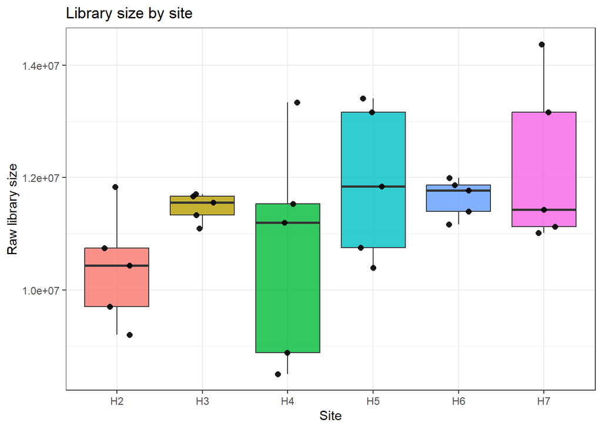

```r
p_libsize <- ggplot2::ggplot(sample_qc, ggplot2::aes(x = site, y = library_size, fill = site)) +
  ggplot2::geom_boxplot(outlier.shape = NA, alpha = 0.8) +
  ggplot2::geom_jitter(width = 0.15, size = 2, alpha = 0.9) +
  ggplot2::labs(title = "Library size by site", x = "Site", y = "Raw library size") +
  ggplot2::theme_bw() +
  ggplot2::theme(legend.position = "none")

p_libsize
```

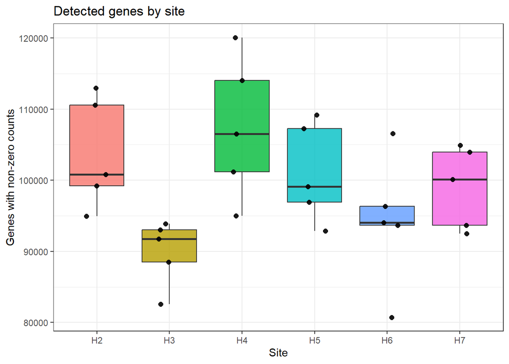

```r
save_plot_dual(p_libsize, "01_library_size_by_site", width = 8, height = 5, dpi = plot_dpi)

p_detected <- ggplot2::ggplot(sample_qc, ggplot2::aes(x = site, y = detected_genes, fill = site)) +
  ggplot2::geom_boxplot(outlier.shape = NA, alpha = 0.8) +
  ggplot2::geom_jitter(width = 0.15, size = 2, alpha = 0.9) +
  ggplot2::labs(title = "Detected genes by site", x = "Site", y = "Genes with non-zero counts") +
  ggplot2::theme_bw() +
  ggplot2::theme(legend.position = "none")

p_detected
```

```r
save_plot_dual(p_detected, "02_detected_genes_by_site", width = 8, height = 5, dpi = plot_dpi)
```

The German subset comprised 30 samples distributed across six Holtemme sites, with broadly comparable library sizes and numbers of detected genes across the gradient. Although some vari- ation among individual samples was evident, there was no strong site-wide imbalance suggesting systematic technical bias in sequencing depth. One H6 sample showed somewhat reduced gene detection relative to the rest, but overall the sample-level QC metrics indicate that the dataset is technically consistent enough for downstream unsupervised ordination and clustering analyses.

# 9 6. Low-count filtering

A mild low-count filter is applied before ordination to reduce instability caused by genes with extremely sparse expression. This does not aim to define a final expression universe for later differential expression analysis; it simply improves robustness for global structure analyses.

Here, genes are retained if they have at least 10 counts in at least 3 samples.

```r
keep_genes <- rowSums(counts_mat >= min_count) >= min_samples
counts_filt <- counts_mat[keep_genes, , drop = FALSE]

filter_summary <- data.frame(
  metric = c("genes_raw", "genes_after_filter", "genes_removed", "samples_retained"),
  value = c(
    nrow(counts_mat),
    nrow(counts_filt),
    nrow(counts_mat) - nrow(counts_filt),
    ncol(counts_filt)
  )
)

write_table_safe(filter_summary, "filtering_summary.csv")

knitr::kable(
  filter_summary,
  caption = "Summary of low-count filtering.",
  row.names = FALSE
)
```

Summary of low-count filtering.

| metric | value |
| --- | --- |
| genes_raw | 443656 |
| genes_after_filter | 151508 |
| genes_removed | 292148 |
| samples_retained | 30 |

Low-count filtering reduced the dataset from 443,656 to 151,508 genes while retaining all 30 samples. This represents a substantial but expected reduction for a de novo transcriptome, where many features are weakly expressed or only sporadically detected. The filtered matrix therefore preserves broad transcriptome-wide information while removing a large number of low-information features that could otherwise add noise to multivariate analyses.

# 10 7. Variance-stabilizing transformation (blind)

For PCA and distance-based analyses, raw counts are not ideal because variance strongly depends on the mean. We therefore apply a blind VST using DESeq2. The transformation stabilizes the variance across the dynamic range while deliberately avoiding group-informed modelling, which is appropriate here because this section is exploratory rather than contrast-driven.

```r
dds <- DESeq2::DESeqDataSetFromMatrix(
  countData = counts_filt,
  colData = meta,
  design = ~ site
)

dds <- DESeq2::estimateSizeFactors(dds)
vsd <- DESeq2::vst(dds, blind = TRUE)
vst_mat <- SummarizedExperiment::assay(vsd)

readr::write_tsv(
  tibble::rownames_to_column(as.data.frame(vst_mat), "gene_id"),
  file.path(matrices_dir, "vst_matrix_germany.tsv")
)
```

A blind variance-stabilizing transformation was then applied to the filtered count matrix to make sample-to-sample comparisons more robust across the full dynamic range of expression values. Because this section is intended to describe global structure rather than fit contrasts, the use of a blind transformation is appropriate and ensures that the ordination reflects broad transcriptomic relationships among samples rather than model-informed group separation.

# 11 8. Principal component analysis (PCA)

PCA provides the first compact view of transcriptome-wide structure across samples. In this context, it helps assess whether site identity aligns with the major axes of variation and whether downstream samples appear to diverge gradually, abruptly, or not at all.

```r
# Shared Figure 2 styling constants
panel_border_col <- "black"
panel_border_lwd <- 0.45
panel_grid_col <- "grey88"
panel_grid_lwd <- 0.35

pca <- stats::prcomp(t(vst_mat), center = TRUE, scale. = FALSE)
percent_var <- (pca$sdev^2) / sum(pca$sdev^2)

pca_scores <- as.data.frame(pca$x)
pca_scores$sample <- rownames(pca_scores)

pca_scores <- dplyr::left_join(
  pca_scores,
  meta,
  by = "sample"
)

site_palette <- c(
  H2 = "#E69F00",
  H3 = "#56B4E9",
  H4 = "#009E73",
  H5 = "#0072B2",
  H6 = "#CC79A7",
  H7 = "#D55E00"
)

site_levels_use <- names(site_palette)[
  names(site_palette) %in% unique(as.character(pca_scores$site))
]

site_palette_use <- site_palette[site_levels_use]

pca_scores <- pca_scores %>%
  dplyr::mutate(
    site = factor(as.character(site), levels = site_levels_use)
  )

pca_var_table <- data.frame(
  PC = paste0("PC", seq_along(percent_var)),
  eigenvalue = pca$sdev^2,
  proportion_variance = percent_var,
  cumulative_variance = cumsum(percent_var)
)

write_table_safe(pca_scores, "pca_sample_scores.csv")
write_table_safe(pca_var_table, "pca_variance_explained.csv")

knitr::kable(
  head(pca_var_table, 10),
  digits = 3,
  caption = "Variance explained by the first principal components.",
  row.names = FALSE
)
```

Variance explained by the first principal components.

| PC | eigenvalue | proportion_variance | cumulative_variance |
| --- | --- | --- | --- |
| PC1 | 21276.533 | 0.092 | 0.092 |
| PC2 | 16127.923 | 0.070 | 0.162 |
| PC3 | 14387.784 | 0.062 | 0.224 |
| PC4 | 11425.717 | 0.049 | 0.273 |
| PC5 | 10488.356 | 0.045 | 0.319 |
| PC6 | 9345.656 | 0.040 | 0.359 |
| PC7 | 9166.617 | 0.040 | 0.399 |
| PC8 | 8788.553 | 0.038 | 0.437 |
| PC9 | 8225.052 | 0.036 | 0.472 |
| PC10 | 7628.061 | 0.033 | 0.505 |

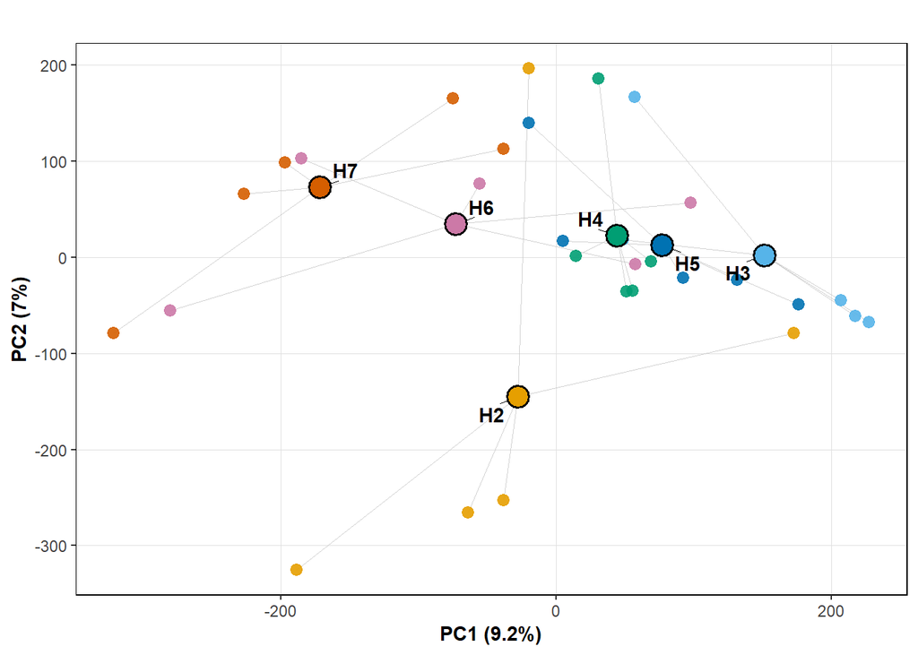

```r
pca_centroids_plot <- pca_scores %>%
  dplyr::group_by(site) %>%
  dplyr::summarise(
    PC1 = mean(PC1, na.rm = TRUE),
    PC2 = mean(PC2, na.rm = TRUE),
    .groups = "drop"
  ) %>%
  dplyr::mutate(
    site = factor(as.character(site), levels = site_levels_use)
  )

pca_segment_df <- pca_scores %>%
  dplyr::select(sample, site, PC1, PC2) %>%
  dplyr::left_join(
    pca_centroids_plot %>%
      dplyr::rename(
        PC1_centroid = PC1,
        PC2_centroid = PC2
      ),
    by = "site"
  )

p_pca12 <- ggplot2::ggplot() +
  ggplot2::geom_segment(
    data = pca_segment_df,
    ggplot2::aes(
      x = PC1,
      y = PC2,
      xend = PC1_centroid,
      yend = PC2_centroid
    ),
    inherit.aes = FALSE,
    linewidth = 0.35,
    colour = "grey75",
    alpha = 0.7
  ) +
  ggplot2::geom_point(
    data = pca_scores,
    ggplot2::aes(
      x = PC1,
      y = PC2,
      colour = site
    ),
    size = 2.8,
    alpha = 0.9
  ) +
  ggplot2::geom_point(
    data = pca_centroids_plot,
    ggplot2::aes(
      x = PC1,
      y = PC2,
      fill = site
    ),
    shape = 21,
    size = 5.2,
    stroke = 0.8,
    colour = "black"
  ) +
  ggrepel::geom_text_repel(
    data = pca_centroids_plot,
    ggplot2::aes(
      x = PC1,
      y = PC2,
      label = site
    ),
    inherit.aes = FALSE,
    size = 3.8,
    fontface = "bold",
    box.padding = 0.4,
    point.padding = 0.35,
    seed = 123,
    min.segment.length = 0,
    segment.size = 0.35
  ) +
  ggplot2::scale_colour_manual(
    values = site_palette_use,
    drop = FALSE
  ) +
  ggplot2::scale_fill_manual(
    values = site_palette_use,
    drop = FALSE
  ) +
  ggplot2::labs(
    title = "",
    x = paste0("PC1 (", round(percent_var[1] * 100, 1), "%)"),
    y = paste0("PC2 (", round(percent_var[2] * 100, 1), "%)")
  ) +
  ggplot2::theme_bw(base_size = 11) +
  ggplot2::theme(
    legend.position = "none",

    panel.background = ggplot2::element_rect(
      fill = "white",
      colour = NA
    ),
    plot.background = ggplot2::element_rect(
      fill = "white",
      colour = NA
    ),

    panel.grid.major = ggplot2::element_line(
      colour = panel_grid_col,
      linewidth = panel_grid_lwd
    ),
    panel.grid.minor = ggplot2::element_blank(),

    panel.border = ggplot2::element_rect(
      colour = panel_border_col,
      fill = NA,
      linewidth = panel_border_lwd
    ),

    axis.title = ggplot2::element_text(
      face = "bold",
      colour = "black"
    ),
    axis.text = ggplot2::element_text(
      colour = "grey25"
    ),

    plot.margin = ggplot2::margin(6, 6, 6, 6)
  )

p_pca12
```

```r
save_plot_dual(
  p_pca12,
  "04_pca_pc1_pc2_publication",
  width = 6.2,
  height = 5.4,
  dpi = 600
)
```

# 12 9. Scree plot

The scree plot helps determine how concentrated the variance is in the leading components. This is useful when interpreting whether global structure is dominated by one or a few axes or spread more diffusely across the transcriptome.

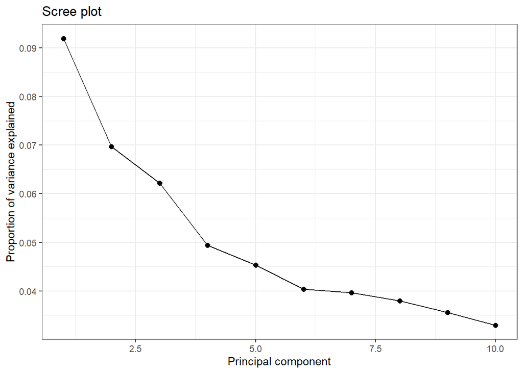

```r
p_scree <- ggplot2::ggplot(
  pca_var_table[seq_len(min(10, nrow(pca_var_table))), , drop = FALSE],
  ggplot2::aes(x = seq_len(min(10, nrow(pca_var_table))), y = proportion_variance)
) +
  ggplot2::geom_line() +
  ggplot2::geom_point(size = 2) +
  ggplot2::labs(
    title = "Scree plot",
    x = "Principal component",
    y = "Proportion of variance explained"
  ) +
  ggplot2::theme_bw()

p_scree
```

```r
save_plot_dual(p_scree, "05_scree_plot", width = 6, height = 4.5, dpi = plot_dpi)
```

# 13 10. Sample-to-sample distances and hierarchical clustering

PCA is informative but compresses the data into a small number of axes. Distance-based summaries complement PCA by examining the overall similarity structure across all retained genes.

The sample-distance heatmap and hierarchical clustering help reveal whether samples cluster pri- marily by site, whether site groups are compact, and whether any samples show unusual placement relative to their expected group.

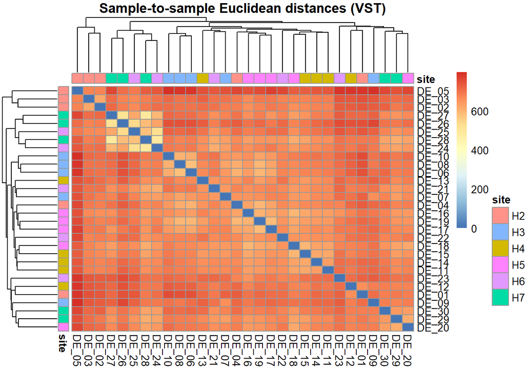

```r
sample_dist <- as.matrix(stats::dist(t(vst_mat), method = "euclidean"))

readr::write_tsv(
  tibble::rownames_to_column(as.data.frame(sample_dist), "sample"),
  file.path(matrices_dir, "sample_distance_matrix.tsv")
)

annotation_col <- data.frame(site = meta$site)
rownames(annotation_col) <- meta$sample

pheatmap::pheatmap(
  sample_dist,
  clustering_distance_rows = "euclidean",
  clustering_distance_cols = "euclidean",
  clustering_method = "complete",
  annotation_col = annotation_col,
  annotation_row = annotation_col,
  main = "Sample-to-sample Euclidean distances (VST)"
)
```

[figure not shown]

```r
png(file.path(plots_dir, "06_sample_distance_heatmap.png"), width = 8, height = 7, units = "in", res = plot_dpi)
pheatmap::pheatmap(
  sample_dist,
  clustering_distance_rows = "euclidean",
  clustering_distance_cols = "euclidean",
  clustering_method = "complete",
  annotation_col = annotation_col,
  annotation_row = annotation_col,
  main = "Sample-to-sample Euclidean distances (VST)"
)
```

```r
dev.off()
```

```r
pdf(file.path(plots_dir, "06_sample_distance_heatmap.pdf"), width = 8, height = 7)
pheatmap::pheatmap(
  sample_dist,
  clustering_distance_rows = "euclidean",
  clustering_distance_cols = "euclidean",
  clustering_method = "complete",
  annotation_col = annotation_col,
  annotation_row = annotation_col,
  main = "Sample-to-sample Euclidean distances (VST)"
)
dev.off()
```

```r
hc <- stats::hclust(stats::dist(t(vst_mat), method = "euclidean"), method = "complete")
plot(hc, main = "Hierarchical clustering of samples (VST)", xlab = "", sub = "")

pdf(file.path(plots_dir, "07_hierarchical_clustering_dendrogram.pdf"), width = 8, height = 6)
plot(hc, main = "Hierarchical clustering of samples (VST)", xlab = "", sub = "")
dev.off()
```

[output not shown]

```r
png(file.path(plots_dir, "07_hierarchical_clustering_dendrogram.png"), width = 8, height = 6, units = "in", res = plot_dpi)
plot(hc, main = "Hierarchical clustering of samples (VST)", xlab = "", sub = "")
dev.off()
```

# 14 11. Heatmap of top variable genes

A heatmap of the most variable genes gives a more granular view of coordinated sample structure. Unlike PCA, which summarizes variance in low-dimensional space, this plot helps visualize whether groups of samples share broader expression similarity across the genes contributing most strongly to transcriptomic differentiation.

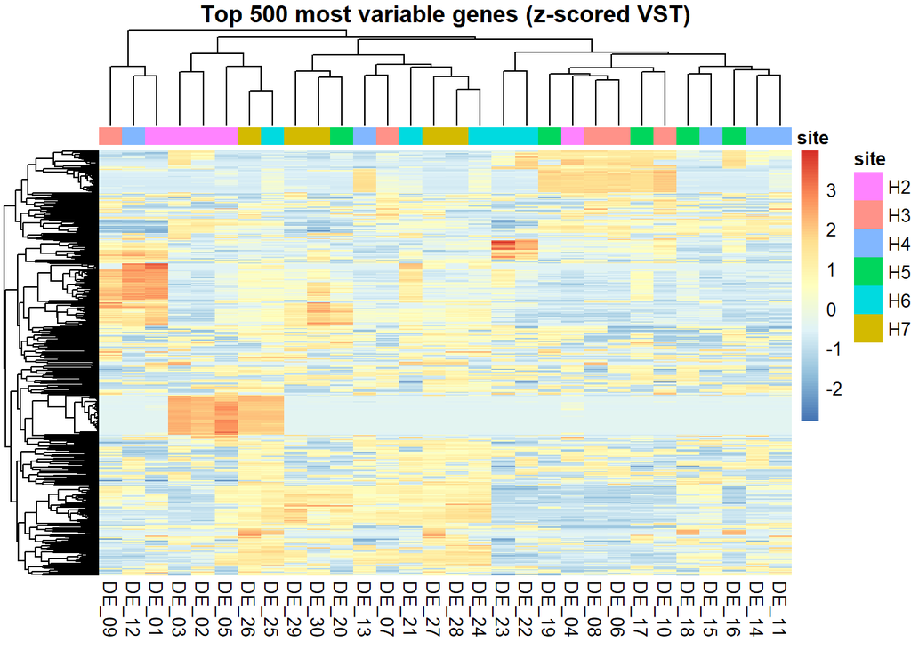

```r
gene_var <- apply(vst_mat, 1, stats::var, na.rm = TRUE)
top_n_use <- min(ntop_heatmap, length(gene_var))
top_genes <- names(sort(gene_var, decreasing = TRUE))[seq_len(top_n_use)]

vst_top <- vst_mat[top_genes, , drop = FALSE]
vst_top_z <- t(scale(t(vst_top)))

pheatmap::pheatmap(
  vst_top_z,
  show_rownames = FALSE,
  annotation_col = annotation_col,
  main = paste0("Top ", top_n_use, " most variable genes (z-scored VST)")
)
```

```r
pheatmap::pheatmap(
  vst_top_z,
  show_rownames = FALSE,
  annotation_col = annotation_col,
  main = paste0("Top ", top_n_use, " most variable genes (z-scored VST)"),
  filename = file.path(plots_dir, "08_top_variable_genes_heatmap.png"),
  width = 8,
  height = 10
)

pdf(file.path(plots_dir, "08_top_variable_genes_heatmap.pdf"), width = 8, height = 10)
pheatmap::pheatmap(
  vst_top_z,
  show_rownames = FALSE,
  annotation_col = annotation_col,
  main = paste0("Top ", top_n_use, " most variable genes (z-scored VST)")
)
dev.off()
```

The heatmap of the 500 most variable genes showed coordinated expression blocks across subsets of samples, again supporting structured transcriptomic differentiation among sites. However, these modules were not uniquely site-specific and several extended across more than one station. This suggests that global site effects are carried by partially shared expression programs rather than by completely distinct site-restricted signatures.

# 15 12. Formal test of site-level transcriptome structure

Ordination plots can suggest grouping, but visual separation alone should not be overinterpreted. We therefore add a formal multivariate test of site structure using PERMANOVA, together with a dispersion test to assess whether differences among sites may partly reflect unequal within-site spread.

These tests do not identify biological mechanisms, but they strengthen the descriptive evaluation of whether site identity organizes transcriptomic variance.

```r
adonis_res <- vegan::adonis2(stats::dist(t(vst_mat), method = "euclidean") ~ site, data = meta, permutations = 999)
adonis_df <- as.data.frame(adonis_res)
adonis_df <- tibble::rownames_to_column(adonis_df, "term")
write_table_safe(adonis_df, "adonis_site_effect.csv")

beta_obj <- vegan::betadisper(stats::dist(t(vst_mat), method = "euclidean"), group = meta$site)

beta_anova <- as.data.frame(stats::anova(beta_obj))
beta_anova <- tibble::rownames_to_column(beta_anova, "term")
write_table_safe(beta_anova, "betadisper_anova.csv")

beta_perm <- vegan::permutest(beta_obj, permutations = 999)
beta_perm_df <- as.data.frame(beta_perm$tab)
beta_perm_df <- tibble::rownames_to_column(beta_perm_df, "term")
write_table_safe(beta_perm_df, "betadisper_permutation.csv")

knitr::kable(
  adonis_df,
  digits = 4,
  caption = "PERMANOVA for site effect on global transcriptome structure.",
  row.names = FALSE
)
```

PERMANOVA for site effect on global transcriptome structure.

| term | Df | SumOfSqs | R2 | F | Pr(>F) |
| --- | --- | --- | --- | --- | --- |
| Model | 5 | 1555995 | 0.2319 | 1.4494 | 0.001 |
| Residual | 24 | 5153033 | 0.7681 | NA | NA |
| Total | 29 | 6709029 | 1.0000 | NA | NA |

```r
knitr::kable(
  beta_anova,
  digits = 4,
  caption = "ANOVA for homogeneity of multivariate dispersion.",
  row.names = FALSE
)
```

ANOVA for homogeneity of multivariate dispersion.

| term | Df | Sum Sq | Mean Sq | F value | Pr(>F) |
| --- | --- | --- | --- | --- | --- |
| Groups | 5 | 11399.75 | 2279.950 | 1.0456 | 0.4142 |
| Residuals | 24 | 52332.41 | 2180.517 | NA | NA |

```r
knitr::kable(
  beta_perm_df,
  digits = 4,
  caption = "Permutation test for homogeneity of multivariate dispersion.",
  row.names = FALSE
)
```

Permutation test for homogeneity of multivariate dispersion.

| term | Df | Sum Sq | Mean Sq | F | N.Perm | Pr(>F) |
| --- | --- | --- | --- | --- | --- | --- |
| Groups | 5 | 11399.75 | 2279.950 | 1.0456 | 999 | 0.413 |
| Residuals | 24 | 52332.41 | 2180.517 | NA | NA | NA |

Formal multivariate testing confirmed that site identity contributes significantly to transcriptome- wide structure. PERMANOVA detected a significant site effect, indicating that a substantial fraction of the variance in the Euclidean distance matrix was associated with differences among sites. In contrast, multivariate dispersion did not differ significantly among sites, supporting the interpreta- tion that the observed site effect reflects centroid separation rather than unequal within-site spread.

# 16 13. Outlier diagnostics

Because field-collected samples can show individual-level variability unrelated to clear technical failure, potential outliers are screened cautiously. Here, we quantify each sample’s Euclidean dis- tance to its own site centroid in PCA space and flag observations lying beyond the within-site upper whisker rule.

```r
pcs_use_outlier <- seq_len(min(5, ncol(pca$x)))
pc_cols_outlier <- colnames(pca$x)[pcs_use_outlier]

site_centroids_pca <- aggregate(
  pca$x[, pcs_use_outlier, drop = FALSE],
  by = list(site = meta$site),
  FUN = mean
)

stopifnot(all(pc_cols_outlier %in% colnames(site_centroids_pca)))
stopifnot(!"site" %in% pc_cols_outlier)

sample_to_centroid <- data.frame(
  sample = rownames(pca$x),
  site = meta$site,
  stringsAsFactors = FALSE
)

sample_to_centroid$distance_to_site_centroid <- vapply(seq_len(nrow(sample_to_centroid)), function(i) {
  s <- as.character(sample_to_centroid$site[i])
  sample_vec <- pca$x[i, pcs_use_outlier, drop = TRUE]
  centroid_vec <- as.numeric(site_centroids_pca[site_centroids_pca$site == s, pc_cols_outlier, drop = TRUE])
  sqrt(sum((sample_vec - centroid_vec)^2))
}, numeric(1))

outlier_flags <- do.call(
  rbind,
  lapply(split(sample_to_centroid, sample_to_centroid$site), function(df) {
    q1 <- stats::quantile(df$distance_to_site_centroid, probs = 0.25, na.rm = TRUE)
    q3 <- stats::quantile(df$distance_to_site_centroid, probs = 0.75, na.rm = TRUE)
    iqr <- q3 - q1
    cutoff <- q3 + 1.5 * iqr
    df$site_outlier_cutoff <- cutoff
    df$potential_outlier <- df$distance_to_site_centroid > cutoff
    df
  })
)

rownames(sample_to_centroid) <- NULL
rownames(outlier_flags) <- NULL

write_table_safe(
  sample_to_centroid[, c("sample", "site", "distance_to_site_centroid")],
  "sample_distance_to_site_centroid.csv"
)

write_table_safe(
  outlier_flags[, c("sample", "site", "distance_to_site_centroid", "site_outlier_cutoff", "potential_outlier")],
  "potential_outliers_by_site.csv"
)

outlier_table <- outlier_flags[, c(
  "sample",
  "site",
  "distance_to_site_centroid",
  "site_outlier_cutoff",
  "potential_outlier"
)]
rownames(outlier_table) <- NULL

knitr::kable(
  outlier_table,
  digits = 3,
  caption = "Potential outlier flags based on within-site distance to centroid.",
  row.names = FALSE
)
```

Potential outlier flags based on within-site distance to centroid.

| sample | site | distance_to_site_centroid | site_outlier_cutoff | potential_outlier |
| --- | --- | --- | --- | --- |
| DE_05 | H2 | 292.824 | 540.678 | FALSE |
| DE_04 | H2 | 300.078 | 540.678 | FALSE |
| DE_03 | H2 | 139.678 | 540.678 | FALSE |
| DE_02 | H2 | 108.963 | 540.678 | FALSE |
| DE_01 | H2 | 371.765 | 540.678 | FALSE |
| DE_10 | H3 | 116.885 | 254.757 | FALSE |
| DE_09 | H3 | 295.660 | 254.757 | TRUE |
| DE_08 | H3 | 122.965 | 254.757 | FALSE |
| DE_07 | H3 | 175.682 | 254.757 | FALSE |
| DE_06 | H3 | 150.621 | 254.757 | FALSE |
| DE_15 | H4 | 74.657 | 285.369 | FALSE |
| DE_14 | H4 | 87.975 | 285.369 | FALSE |
| DE_13 | H4 | 166.533 | 285.369 | FALSE |
| DE_12 | H4 | 296.364 | 285.369 | TRUE |
| DE_11 | H4 | 87.309 | 285.369 | FALSE |
| DE_20 | H5 | 199.686 | 184.103 | TRUE |
| DE_19 | H5 | 140.302 | 184.103 | FALSE |
| DE_18 | H5 | 111.101 | 184.103 | FALSE |
| DE_17 | H5 | 128.967 | 184.103 | FALSE |
| DE_16 | H5 | 79.033 | 184.103 | FALSE |
| DE_25 | H6 | 258.892 | 355.767 | FALSE |
| DE_24 | H6 | 205.833 | 355.767 | FALSE |
| DE_23 | H6 | 295.360 | 355.767 | FALSE |
| DE_22 | H6 | 194.309 | 355.767 | FALSE |
| DE_21 | H6 | 179.850 | 355.767 | FALSE |
| DE_30 | H7 | 211.904 | 316.046 | FALSE |
| DE_29 | H7 | 226.654 | 316.046 | FALSE |
| DE_28 | H7 | 86.487 | 316.046 | FALSE |
| DE_27 | H7 | 167.059 | 316.046 | FALSE |
| DE_26 | H7 | 245.906 | 316.046 | FALSE |

Outlier screening identified three potential within-site outliers, one each from H3, H4, and H5. These samples were more distant from their site centroids than their site-mates, but none was sufficiently extreme to justify exclusion. They are therefore best interpreted as part of the biological heterogeneity expected in wild populations rather than as evidence of technical failure.

# 17 14. Site-centroid distance summaries

The previous analyses show whether site structure exists, but they do not directly summarize how that structure is distributed along the river sequence. To address this, we calculate distances from each site centroid to the reference site, and also between adjacent site centroids along the river.

These summaries help distinguish two non-exclusive patterns:

- progressive downstream divergence from H2
- sharper local discontinuities between neighboring sites

```r
pcs_use <- seq_len(min(pca_n_axes_for_centroid_dist, ncol(pca$x)))
pc_cols <- colnames(pca$x)[pcs_use]

site_centroids <- aggregate(
  pca$x[, pcs_use, drop = FALSE],
  by = list(site = meta$site),
  FUN = mean
)

site_centroids$site <- factor(site_centroids$site, levels = site_levels_present)
site_centroids <- site_centroids[order(site_centroids$site), , drop = FALSE]
rownames(site_centroids) <- as.character(site_centroids$site)

stopifnot(all(pc_cols %in% colnames(site_centroids)))
stopifnot(!"site" %in% pc_cols)

centroid_distance_axis_audit <- data.frame(
  n_pcs_used = length(pc_cols),
  pc_axes_used = paste(pc_cols, collapse = ";"),
  non_pc_columns_used = any(!grepl("^PC[0-9]+$", pc_cols)),
  status = "PC columns selected by name; metadata columns excluded",
  stringsAsFactors = FALSE
)

write_table_safe(
  centroid_distance_axis_audit,
  "centroid_distance_axis_audit.csv"
)

ref_vec <- as.numeric(site_centroids[as.character(reference_site), pc_cols, drop = TRUE])

dist_to_ref <- data.frame(
  site = as.character(site_centroids$site),
  centroid_distance_to_reference = vapply(seq_len(nrow(site_centroids)), function(i) {
    this_vec <- as.numeric(site_centroids[i, pc_cols, drop = TRUE])
    sqrt(sum((this_vec - ref_vec)^2))
  }, numeric(1)),
  n_pcs_used = length(pc_cols),
  pc_axes_used = paste(pc_cols, collapse = ";"),
  stringsAsFactors = FALSE
)

write_table_safe(dist_to_ref, "site_centroid_distance_to_reference.csv")

adjacent_dist <- do.call(
  rbind,
lapply(seq_len(nrow(site_centroids) - 1), function(i) {
    a <- as.numeric(site_centroids[i, pc_cols, drop = TRUE])
    b <- as.numeric(site_centroids[i + 1, pc_cols, drop = TRUE])
    data.frame(
      upstream = as.character(site_centroids$site[i]),
      downstream = as.character(site_centroids$site[i + 1]),
      centroid_distance = sqrt(sum((a - b)^2)),
      n_pcs_used = length(pc_cols),
      pc_axes_used = paste(pc_cols, collapse = ";"),
      stringsAsFactors = FALSE
    )
  })
)

adjacent_dist$contrast_file <- paste(adjacent_dist$upstream, adjacent_dist$downstream, sep = "_to_")
adjacent_dist$contrast_plot <- paste(adjacent_dist$upstream, adjacent_dist$downstream, sep = " -> ")

write_table_safe(adjacent_dist, "adjacent_site_centroid_distances.csv")
```

## 17.1 14a. Distance to reference centroid

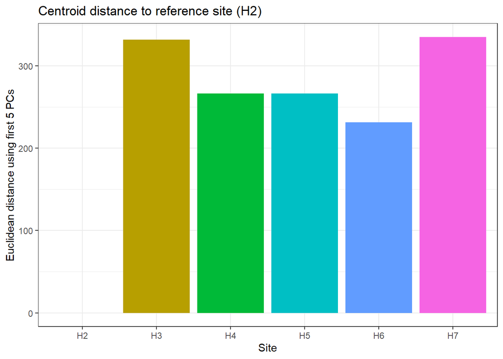

```r
p_refdist <- ggplot2::ggplot(dist_to_ref, ggplot2::aes(x = site, y = centroid_distance_to_reference, fill = site)) +
  ggplot2::geom_col() +
  ggplot2::labs(
    title = "Centroid distance to reference site (H2)",
    x = "Site",
    y = paste0("Euclidean distance using first ", length(pcs_use), " PCs")
  ) +
  ggplot2::theme_bw() +
  ggplot2::theme(legend.position = "none")

p_refdist
```

```r
save_plot_dual(p_refdist, "10_site_centroid_distance_to_reference", width = 8, height = 5, dpi = plot_dpi)
```

## 17.2 14b. Distances between adjacent site centroids

```r
# Adjacent site centroid distances in PCA space

# Shared Figure 2 styling constants
# Keep these identical to the PCA panel.
panel_border_col <- "black"
panel_border_lwd <- 0.45
panel_grid_col <- "grey88"
panel_grid_lwd <- 0.35

site_order_centroids <- c(
  "H2",
  "H3",
  "H4",
  "H5",
  "H6",
  "H7"
)

site_centroids_ordered <- site_centroids %>%
  dplyr::mutate(
    site = factor(as.character(site), levels = site_order_centroids)
  ) %>%
  dplyr::arrange(site)

adjacent_dist <- do.call(
  rbind,
  lapply(seq_len(nrow(site_centroids_ordered) - 1), function(i) {
    up <- as.character(site_centroids_ordered$site[i])
    dn <- as.character(site_centroids_ordered$site[i + 1])

    up_vec <- as.numeric(site_centroids_ordered[i, pc_cols, drop = FALSE])
    dn_vec <- as.numeric(site_centroids_ordered[i + 1, pc_cols, drop = FALSE])

    data.frame(
      upstream = up,
      downstream = dn,
      centroid_distance = sqrt(sum((dn_vec - up_vec)^2)),
      n_pcs_used = length(pc_cols),
      pc_axes_used = paste(pc_cols, collapse = ";"),
      stringsAsFactors = FALSE
    )
  })
)

adjacent_dist$contrast <- paste(
  adjacent_dist$upstream,
  adjacent_dist$downstream,
  sep = "_to_"
)

adjacent_dist$contrast_plot <- paste0(
  adjacent_dist$upstream,
  " -> ",
  adjacent_dist$downstream
)

# Highlight the two WWTP-associated step changes used in the publication panel
adjacent_dist$is_wwtp_transition <- adjacent_dist$contrast %in% c(
  "H2_to_H3",
  "H5_to_H6"
)

write_table_safe(
  adjacent_dist,
  "adjacent_site_centroid_distances.csv"
)

knitr::kable(
  adjacent_dist,
  digits = 3,
  caption = "Distances between adjacent site centroids in PCA space.",
  row.names = FALSE
)
```

Distances between adjacent site centroids in PCA space.

| upstream | downstream | centroid_distance | n_pcs_used | pc_axes_used | contrast | contrast_plot | is_wwtp_transition |
| --- | --- | --- | --- | --- | --- | --- | --- |
| H2 | H3 | 332.081 | 5 | PC1;PC2;PC3;PC4;PC5 | H2_to_H3 | H2 -> H3 | TRUE |
| H3 | H4 | 326.677 | 5 | PC1;PC2;PC3;PC4;PC5 | H3_to_H4 | H3 -> H4 | FALSE |
| H4 | H5 | 163.783 | 5 | PC1;PC2;PC3;PC4;PC5 | H4_to_H5 | H4 -> H5 | FALSE |
| H5 | H6 | 184.484 | 5 | PC1;PC2;PC3;PC4;PC5 | H5_to_H6 | H5 -> H6 | TRUE |
| H6 | H7 | 129.179 | 5 | PC1;PC2;PC3;PC4;PC5 | H6_to_H7 | H6 -> H7 | FALSE |

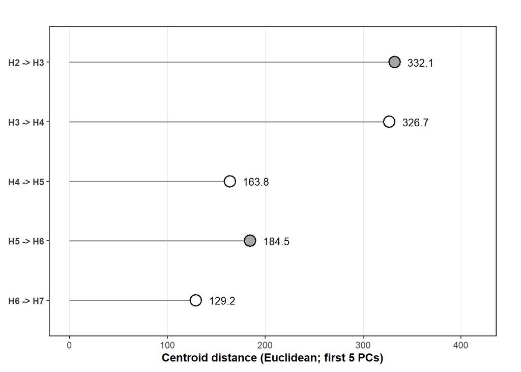

```r
adjacent_dist_plot <- adjacent_dist %>%
  dplyr::mutate(
    contrast_plot = factor(
      contrast_plot,
      levels = rev(c(
        "H2 -> H3",
        "H3 -> H4",
        "H4 -> H5",
        "H5 -> H6",
        "H6 -> H7"
      ))
    )
  )

label_offset_adj <- max(
  adjacent_dist_plot$centroid_distance,
  na.rm = TRUE
) * 0.04

xmax_adj <- max(
  adjacent_dist_plot$centroid_distance,
  na.rm = TRUE
) * 1.25

p_adjacent <- ggplot2::ggplot(
  adjacent_dist_plot,
  ggplot2::aes(
    x = centroid_distance,
    y = contrast_plot
  )
) +
  ggplot2::geom_segment(
    ggplot2::aes(
      x = 0,
      xend = centroid_distance,
      y = contrast_plot,
      yend = contrast_plot
    ),
    linewidth = 0.7,
    colour = "grey60"
  ) +
  ggplot2::geom_point(
    ggplot2::aes(
      fill = is_wwtp_transition
    ),
    shape = 21,
    size = 4.6,
    stroke = 1.0,
    colour = "black",
    show.legend = FALSE
  ) +
  ggplot2::geom_text(
    ggplot2::aes(
      x = centroid_distance + label_offset_adj,
      label = sprintf("%.1f", centroid_distance)
    ),
    hjust = 0,
    size = 3.6,
    colour = "black"
  ) +
  ggplot2::scale_fill_manual(
    values = c(
      "TRUE" = "grey65",
      "FALSE" = "white"
    ),
    guide = "none"
  ) +
  ggplot2::coord_cartesian(
    xlim = c(0, xmax_adj),
    clip = "off"
  ) +
  ggplot2::labs(
    title = "",
    x = paste0(
      "Centroid distance (Euclidean; first ",
      length(pcs_use),
      " PCs)"
    ),
    y = NULL
  ) +
  ggplot2::theme_bw(base_size = 11) +
  ggplot2::theme(
    legend.position = "none",

    panel.background = ggplot2::element_rect(
      fill = "white",
      colour = NA
    ),
    plot.background = ggplot2::element_rect(
      fill = "white",
      colour = NA
    ),

    panel.grid.minor = ggplot2::element_blank(),
    panel.grid.major.y = ggplot2::element_blank(),
    panel.grid.major.x = ggplot2::element_line(
      colour = panel_grid_col,
      linewidth = panel_grid_lwd
    ),

    panel.border = ggplot2::element_rect(
      colour = panel_border_col,
      fill = NA,
      linewidth = panel_border_lwd
    ),

    axis.title = ggplot2::element_text(
      face = "bold",
      colour = "black"
    ),
    axis.text.x = ggplot2::element_text(
      colour = "grey25"
    ),
    axis.text.y = ggplot2::element_text(
      face = "bold",
      colour = "grey25"
    ),

    plot.margin = ggplot2::margin(8, 24, 8, 8)
  )

p_adjacent
```

```r
# Main export
save_plot_dual(
  p_adjacent,
  "11_adjacent_site_centroid_distances",
  width = 5.6,
  height = 4.8,
  dpi = 600
)

# Standalone export for manuscript figure assembly
save_plot_dual(
  p_adjacent,
  "Figure2B_adjacent_centroid_distances_publication",
  width = 3.8,
  height = 5.9,
  dpi = 600
)
```

The site-centroid summaries clarified that transcriptomic divergence along the river was not evenly distributed. Relative to H2, some downstream sites were strongly displaced in multivariate space, but the pattern was not monotonic. Adjacent-site distances were largest between H2 and H3 and between H3 and H4, and were smaller for the remaining transitions. This argues against a simple model of steady downstream accumulation of transcriptomic change and instead supports a non-uniform trajectory with stronger early reorganization followed by compara- tively smaller downstream adjustments.

# 18 15. Overall interpretation

Overall, the Holtemme dataset shows significant but moderate site-level structuring of global tran- scriptome profiles in wild Gammarus pulex. Ordination, clustering, variable-gene structure, and formal multivariate testing all support the conclusion that site identity is associated with repro- ducible transcriptomic differences, although these differences remain embedded within substantial within-site heterogeneity. The retention of three mild outliers does not alter that conclusion. At the global-expression level, the dominant pattern is therefore not one of discrete site classes, but of partial organization across the gradient, with the strongest multivariate shifts occurring in the early part of the river sequence.

# 19 16. Results synthesis

A practical outline for writing this Results section is:

1. **Dataset composition and QC** State that 30 German samples from six Holtemme sites were retained, that sequencing depth and gene detection were broadly comparable among sites, and that low-count filtering reduced the matrix to 151,508 genes without removing samples.
2. **Global ordination structure** Describe the PCA as showing moderate but incomplete site-level organization, with substantial overlap among sites and variance distributed across multiple axes rather than dominated by a single component.
3. **Distance-based support for site organization** Use the sample-distance heatmap, dendrogram, and top-variable-gene heatmap to show that site-related similarity exists but is not perfectly discrete.
4. **Formal statistical support** Present the PERMANOVA and dispersion results to show that site identity significantly structures global transcriptome variation and that this result is not driven by unequal within-site dispersion.
5. **Outliers and gradient shape** Note that a small number of samples were flagged as potential within-site outliers but were retained, and conclude with the centroid-distance results showing that the strongest transcriptomic shifts occurred between H2 and H3 and between H3 and H4 rather than accumulating evenly downstream.